# Project1DataExploration

## Graph Average Delinquencies by Loan Status

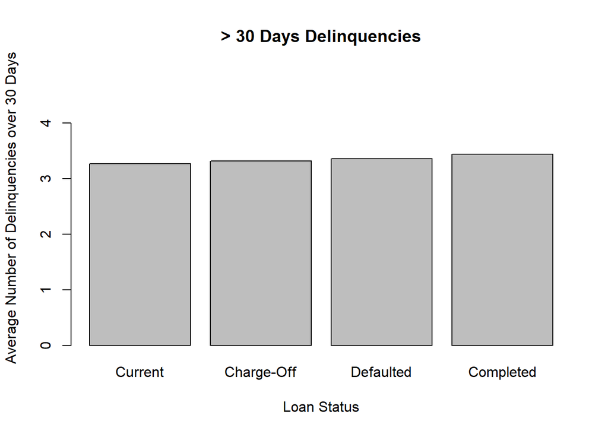

```r
  # Find the average number of delinquencies over 30, 60, and 90 days for Current borrowers.
  s1del30 <- mean(status1$delinquencies_over30_days)
  s1del60 <- mean(status1$delinquencies_over60_days)
  s1del90 <- mean(status1$delinquencies_over90_days)
  # Find the average number of delinquencies over 30, 60, and 90 days for Charge-Off borrowers.
  s2del30 <- mean(status2$delinquencies_over30_days)
  s2del60 <- mean(status2$delinquencies_over60_days)
  s2del90 <- mean(status2$delinquencies_over90_days)
  # Find the average number of delinquencies over 30, 60, and 90 days for Defaulted borrowers.
  s3del30 <- mean(status3$delinquencies_over30_days)
  s3del60 <- mean(status3$delinquencies_over60_days)
  s3del90 <- mean(status3$delinquencies_over90_days)
  # Find the average number of delinquencies over 30, 60, and 90 days for Completed borrowers.
  s4del30 <- mean(status4$delinquencies_over30_days)
  s4del60 <- mean(status4$delinquencies_over60_days)
  s4del90 <- mean(status4$delinquencies_over90_days)

  # Set up the vector to plot >30 days delinquent
  del30 <- c(s1del30, s2del30, s3del30, s4del30)
  del30Max <- max(del30) + 1.5
  # Set up the vector to plot >60 days delinquent
  del60 <- c(s1del60, s2del60, s3del60, s4del60)
  del60Max <- max(del60) + 1.5
  # Set up the vector to plot >90 days delinquent
  del90 <- c(s1del90, s2del90, s3del90, s4del90)
  del90Max <- max(del90) + 1.5

  barplot(del30, ylim = c(0, del30Max), main = "> 30 Days Delinquencies", xlab = "Loan Status",
          ylab = "Average Number of Delinquencies over 30 Days", names.arg = c("Current", "Charge-Off", "Defaulted", "Completed"))
```

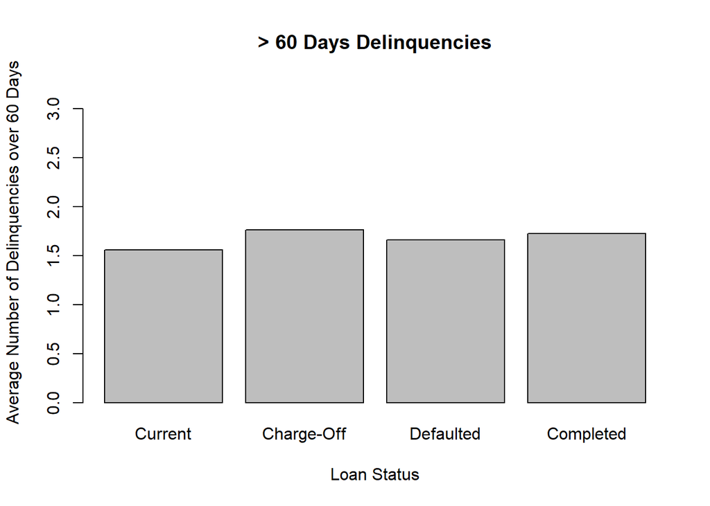

```r
  barplot(del60, ylim = c(0, del60Max), main = "> 60 Days Delinquencies", xlab = "Loan Status",
          ylab = "Average Number of Delinquencies over 60 Days", names.arg = c("Current", "Charge-Off", "Defaulted", "Completed"))
```

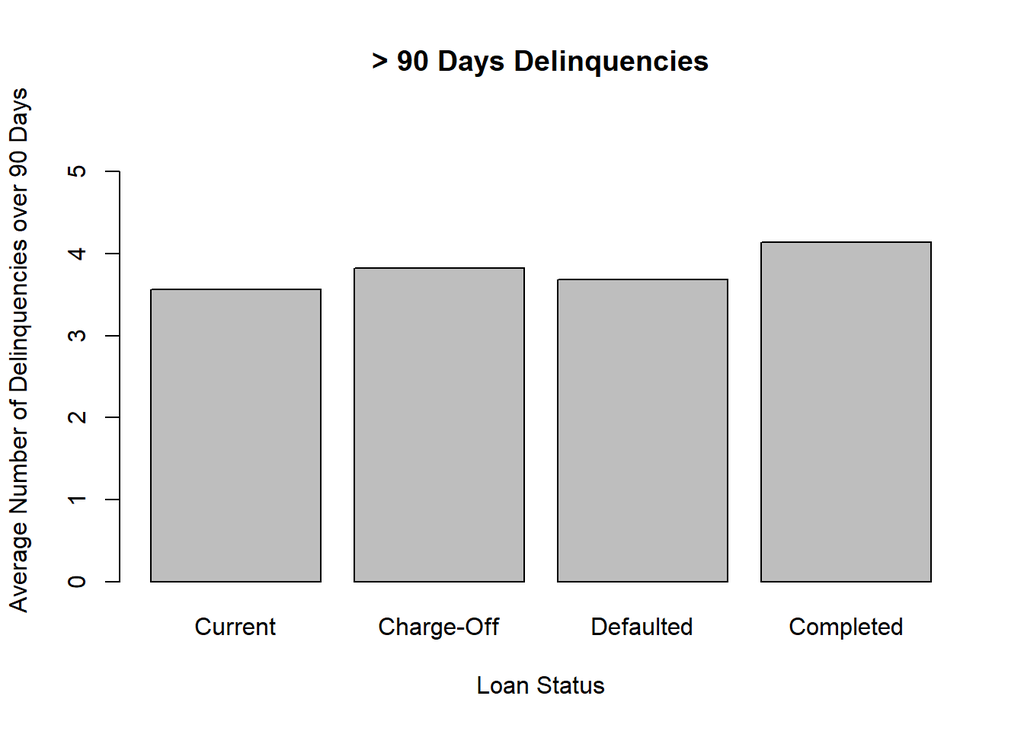

```r
  barplot(del90, ylim = c(0, del90Max), main = "> 90 Days Delinquencies", xlab = "Loan Status",
          ylab = "Average Number of Delinquencies over 90 Days", names.arg = c("Current", "Charge-Off", "Defaulted", "Completed"))
```

> For the first chart, we see the average number of delinquencies over thirty days by loan status. It seems that all categories of borrowers had roughly the same average number of deliquencies over thirty days, about 3.2 delinquencies. As far as the second chart, delinquencies are lower in absolute terms (roughly half of the first chart values). We observe that Charge-Off and Completed borrowers accounted for higher mean delinquencies over sixty days. The same is true for over ninty days. It is likely that the set “> 60 days” also contains many of the same values as “>90 days” which explains the similarity in their summary statistics.

## Delinquencies

```r
tapply(lng$delinquencies_last7_years, lng$loan_status, mean, na.rm=TRUE)
```

```
##        1        2        3        4
## 3.597607 3.897399 3.791478 4.064657
```

> Possible explanations for why completed loans have more defaults than any other loan status could be a factor of time and/or experience with loans. Especially since the vast majority of the loans were used for debt consolidation. It is still surprising that default and charge-off loans didn’t have a higher average default than the actual defaults but perhaps that is a personal bias/expectation.

# Conclusion